# Olympic Medal Hypothesis Testing - EDA

Steven Leung

24/11/2021

# Exploratory Data Analysis

Here is the URL of our data source:

https://github.com/rfordatascience/tidytuesday/tree/master/data/2021/2021-07-27

Direct download links to individual CSV files:

The only file we need for our purpose:

https://github.com/rfordatascience/tidytuesday/raw/master/data/2021/2021-07-27/olympics.csv

Other files:

https://github.com/rfordatascience/tidytuesday/raw/master/data/2021/2021-07-27/athlete_events.csv https://github.com/rfordatascience/tidytuesday/raw/master/data/2021/2021-07-27/noc_regions.csv https://github.com/rfordatascience/tidytuesday/raw/master/data/2021/2021-07-27/regions.csv

Based on the source page, we understand that we really need the `olympics.csv` file which is the cleaned version of the file `athlete.csv`. The other 2 files only contains redundant information as far as our analytic objective is concerned. So we are going to do EDA on the `olympics.csv` file here.

The data dictionary is available here:

https://github.com/rfordatascience/tidytuesday/tree/master/data/2021/2021-07-27#olympicscsv

| variable | class | description |
| --- | --- | --- |
| id | double | Athlete ID |
| name | character | Athlete Name |
| sex | character | Athlete Sex |
| age | double | Athlete Age |
| height | double | Athlete Height in cm |
| weight | double | Athlete weight in kg |
| team | character | Country/Team competing for |
| noc | character | noc region |
| games | character | Olympic games name |
| year | double | Year of olympics |
| season | character | Season either winter or summer |
| city | character | City of Olympic host |
| sport | character | Sport |
| event | character | Specific event |
| medal | character | Medal (Gold, Silver, Bronze or NA) |

Let’s load the data and find out more.

Table 1: Summary information of data

|  | id | name | sex | age | height | weight | team | noc | games | year | season | city | sport | event | medal |
| --- | --- | --- | --- | --- | --- | --- | --- | --- | --- | --- | --- | --- | --- | --- | --- |
|  | Min. : 1 | Length:261642 | Length:261642 | Min. :10.00 | Min. :127.0 | Min. : 25.00 | Length:261642 | Length:261642 | Length:261642 | Min. :1896 | Length:261642 | Length:261642 | Length:261642 | Length:261642 | Length:261642 |
|  | 1st Qu.: 34755 | Class :character | Class :character | 1st Qu.:21.00 | 1st Qu.:168.0 | 1st Qu.: 60.00 | Class :character | Class :character | Class :character | 1st Qu.:1964 | Class :character | Class :character | Class :character | Class :character | Class :character |
|  | Median : 68198 | Mode :character | Mode :character | Median :24.00 | Median :175.0 | Median : 70.00 | Mode :character | Mode :character | Mode :character | Median :1988 | Mode :character | Mode :character | Mode :character | Mode :character | Mode :character |
|  | Mean : 68291 | NA | NA | Mean :25.56 | Mean :175.3 | Mean : 70.71 | NA | NA | NA | Mean :1980 | NA | NA | NA | NA | NA |
|  | 3rd Qu.:102109 | NA | NA | 3rd Qu.:28.00 | 3rd Qu.:183.0 | 3rd Qu.: 79.00 | NA | NA | NA | 3rd Qu.:2004 | NA | NA | NA | NA | NA |
|  | Max. :135571 | NA | NA | Max. :97.00 | Max. :226.0 | Max. :214.00 | NA | NA | NA | Max. :2016 | NA | NA | NA | NA | NA |
|  | NA | NA | NA | NA | NA’s :51574 | NA’s :54263 | NA | NA | NA | NA | NA | NA | NA | NA | NA |

The data, after removing rows with `age` missing because we focus on `age` in our analysis, has 261642 rows and 15 columns. Here are more information as we examine the dataframe.

Let’s also sample a few rows from the data:

Table 2: Sample rows from data

| id | name | sex | age | height | weight | team | noc | games | year | season | city | sport | event | medal |
| --- | --- | --- | --- | --- | --- | --- | --- | --- | --- | --- | --- | --- | --- | --- |
| 53794 | Kjetil Jansrud | M | 24 | 185 | 83 | Norway | NOR | 2010 Winter | 2010 | Winter | Vancouver | Alpine Skiing | Alpine Skiing Men’s Giant Slalom | Silver |
| 61038 | Karel Klannik | M | 34 | NA | NA | Yugoslavia | YUG | 1952 Winter | 1952 | Winter | Oslo | Ski Jumping | Ski Jumping Men’s Normal Hill, Individual | NA |
| 61154 | Nadine Kleinert-Schmitt | F | 24 | 190 | 90 | Germany | GER | 2000 Summer | 2000 | Summer | Sydney | Athletics | Athletics Women’s Shot Put | NA |
| 46882 | Pippa Hayward | F | 26 | 176 | 69 | New Zealand | NZL | 2016 Summer | 2016 | Summer | Rio de Janeiro | Hockey | Hockey Women’s Hockey | NA |
| 22275 | Harvey Wright Cohn | M | 23 | 172 | 61 | United States | USA | 1908 Summer | 1908 | Summer | London | Athletics | Athletics Men’s 3 mile, Team | Silver |

## Age Distribution

Let’s see what the age distribution looks like for all athletes:

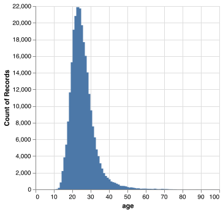

Figure 1: Age distribution

As can be seen above, the age peaks at 23 years old and the distribution is bell-shaped and right-skewed.

## Age vs Numeric features

Let’s explore how age correlates with other numeric features.

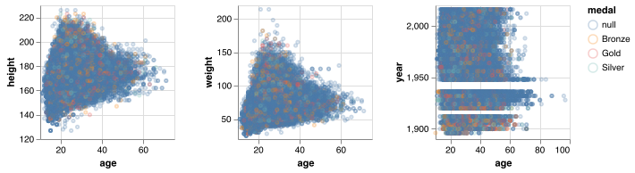

Figure 2: Age vs Numeric features

It seems difficult to visualize when the class imbalance is with `medal` when not having a medal is the majority. Now we try again with the data only with medals and look at the data again.

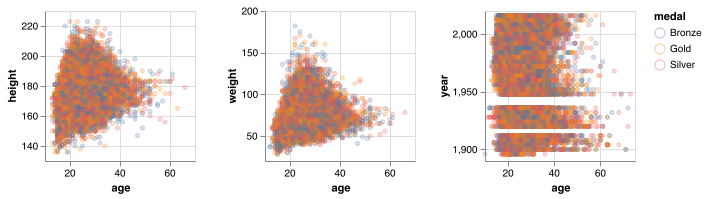

Figure 3: Age vs Numeric features (only with medals)

Some high-level insights:

1. There is some apparently correlation of between height and age and between weight and age for those who got medals; and
2. The maximum age of athletes getting medals seemed to shrink between 1960s and 1980s, and it seemed to increase again till now.

Perhaps we should simply just look at the relationship between age and medals…

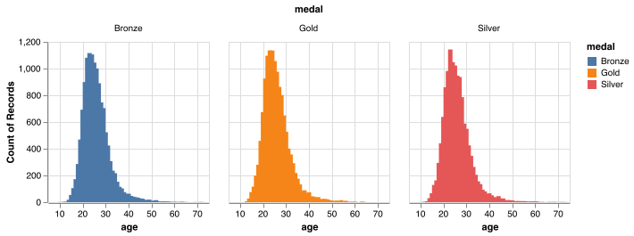

Figure 4: Age vs Medals

All the modes for `Gold`, `Silver` and `Bronze` appear to be the same as the overall age distribution as seen in Figure 1 above.

## Age vs Categorical Features

Now let’s also explore the categorical features.

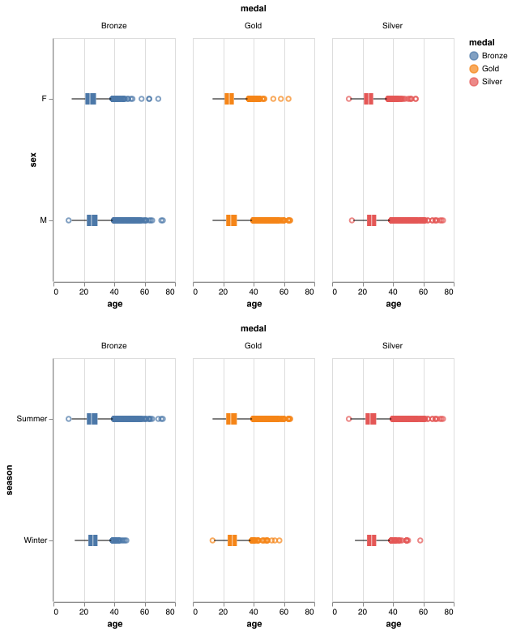

Figure 5: Age vs Categorical features (sex and season)

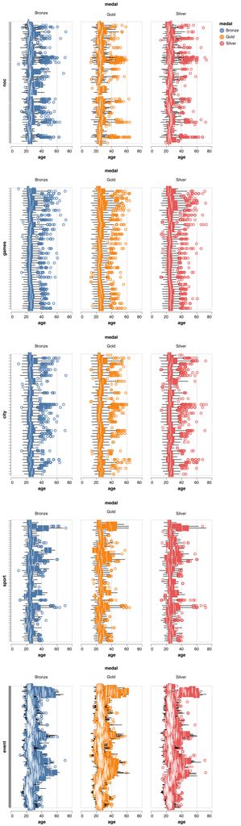

Figure 6: Age vs Categorical features (other features)

### Comments by categorical features:

1. `Sex` - The mail medalists seem to have a higher mean age than female counterparts but not by a lot. The age distribution of male medalists is also more right-skewed compared with female medalists;
2. `season` - The age spread is larger for `summer` over `winter` and the distribution of `summer` is more right-skewed than `winter`.

These 2 categorical features may help if we want expand our analysis into how age relates to the winning of medals.

For the other categorical features, namely `noc`, `games`, `city`, `sport` and `event`:

1. `age` varies greatly across those categorical features; and
2. The 3 medals appears to distribute very similarly with all those features.